# Simple Example

2015-09-04

This vignette produces the example shown in figure 1 in section 1.3 of “Rank conditional coverage and confidence intervals in high dimensional problems.”

The builtin data set `example_params` is a 1000 by 4 matrix containing four sets of parameter values.

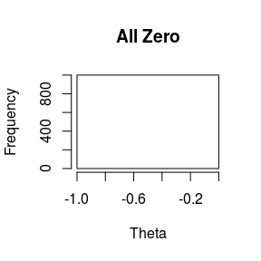

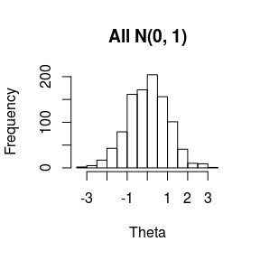

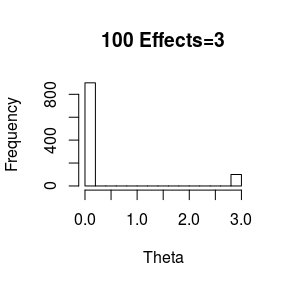

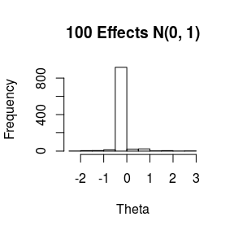

```r
titles <- c("All Zero", "All N(0, 1)", "100 Effects=3", "100 Effects N(0, 1)")
for(i in 1:4){
  hist(example_params[,i], breaks=15, main=titles[i], xlab="Theta")
}
```

The function `example_sim` simulates normally distributed data from a given vector of means and constructs confidence intervals using the five methods described in the paper * naive * oracle rank conditional pivotal intervals * parametric bootstrap intervals * selection adjusted intervals described by Weinstein et al (2013) * sliding thershold variation of the Weinstein et al intervals

The following prduces the simulations shown:

```r
set.seed(6587900)
sim.list <- list()
for(i in 1:4){
  sim.list[[i]] <- example_sim(example_params[,i], n=200, use.abs=FALSE)
}
```

Each simulation object is a list containing matrices of the raw data generated and two 5 by 1000 by 200 arrays giving the coverage and interval width for each of five types of intervals at for each rank over 200 replications (see documentation for `example_sim`).

```r
names(sim.list[[1]])
```

```
#> [1] "Z"        "COVERAGE" "WIDTH"    "simnames"
```

```r
sim.list[[1]]$simnames
```

```
#> [1] "par"    "wfb"    "wfb2"   "oracle" "naive"
```

```r
dim(sim.list[[1]]$COVERAGE)
```

```
#> [1]    5 1000  200
```

```r
dim(sim.list[[1]]$WIDTH)
```

```
#> [1]    5 1000  200
```

## Plotting

Plots can be created with the `plot_coverage` and `plot_width` functions.

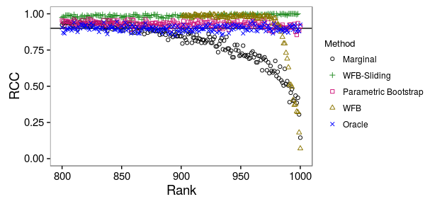

```r
plot_coverage(sim.list[[2]], proportion=0.2,
              cols=c("black", "forestgreen", "deeppink3", "gold4", "blue"),
              shapes= c(1, 3, 0, 2, 4),
              simnames=c("naive", "wfb2", "par", "wfb", "oracle"),
              legend.names = c("Marginal", "WFB-Sliding", "Parametric Bootstrap", "WFB", "Oracle"), legend.position = "right")
```

## A note about absolute value

The functions accompanying “Selection Adjusted Confidence Intervals with More Power to Determine the Sign” By Asaf Weinstein, William Fithian, and Yoav Benjamini JASA (2012) adjust for selection based on a threshold on the absolute value of the estimate. Bootstrap intervals can be constructed ranking by signed or by absolute value – algorithms are only given explicitly for signed ranking so this is used in the example. To construct intervals which rank based on absolute value set `use.abs=TRUE` in the `example_sim` function.